# Challenge 2: Spicing things up with ggplot2

For this week’s Challenge, you will have three different options to explore. I’ve arranged these options in terms of their “spiciness,” or the difficulty of completing the task. You are only required to complete one task, but if you are interested in exploring more than one, feel free!

# 1 🌶 Medium – Ridge Plots

In questions 8-14, you used side-by-side boxplots to visualize the distribution of weight within each species. Boxplots have [substantial flaws](https://www.data-to-viz.com/caveat/boxplot.html), namely that they disguise distributions with multiple modes.

A “superior” alternative is the density plot. However, **ggplot2** does not allow for side-by-side density plots using `geom_density()`. Instead, we will need to make use of the **ggridges** package to create side-by-side density (ridge) plots.

> **For this challenge you are to change the plot you created in question 13 (or 14) to a ridge plots. You will need to install the** ggridges** package and explore the `geom_density_ridges()` function.**

# 2 🌶 🌶 Spicy – Exploring Color Themes

The built in `ggplot()` color scheme may not be what you were looking for, but don’t worry! There are many other color palettes available to use!

You can change the colors used by `ggplot()` a few different ways.

## 2.1 Manual Specification

Add the `scale_color_manual()` or `scale_fill_manual()` functions to your plot and directly specify the colors you want to use. You can either:

- defining a vector of colors right there (e.g. `values = c("blue", "black", "red", "green")`)
- creating a vector of colors using hex numbers and storing it in an object and calling it (see example below)
  - If you are interested in using specific hex colors, I like the [image color picker app](https://imagecolorpicker.com/en) to find the colors I want.

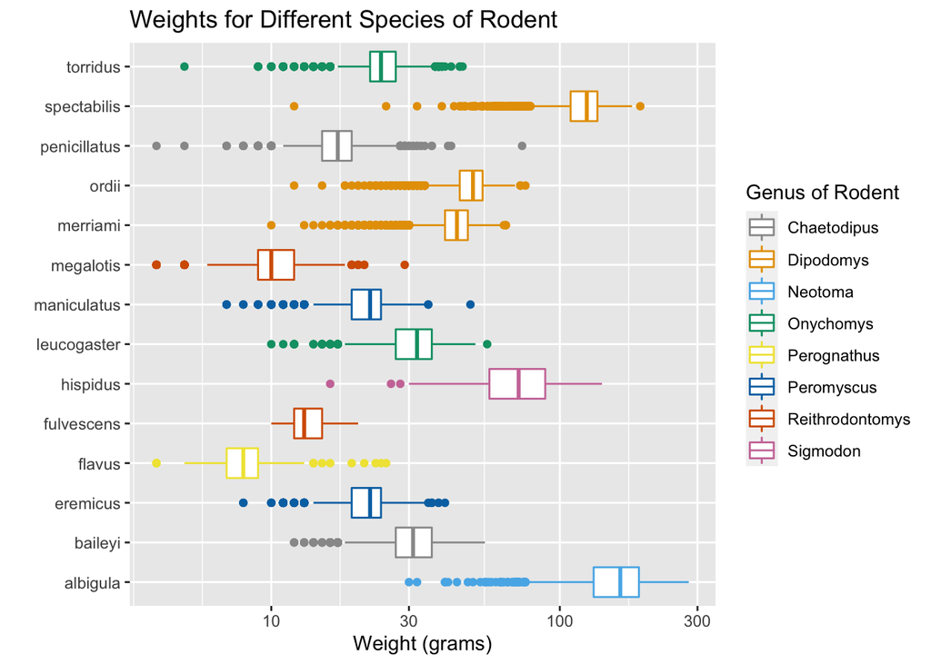

```r
# A color deficient friendly palette with gray:
cdPalette_grey <- c("#999999", "#E69F00", "#56B4E9", "#009E73", "#F0E442",
                    "#0072B2", "#D55E00", "#CC79A7")
# A color deficient friendly palette with black:
cdPalette_blk <- c("#000000", "#E69F00", "#56B4E9", "#009E73", "#F0E442",
                   "#0072B2", "#D55E00", "#CC79A7")

ggplot(data = surveys, aes(x = weight, y = species, color = genus)) +
  geom_boxplot() +
  scale_color_manual(values = cdPalette_grey) +
  labs(title = "Weights for Different Species of Rodent",
       y = "",
       x = "Weight (grams)",
       color = "Genus of Rodent") +
  scale_x_log10()
```

## 2.2 Package Specification

Install a package and use it’s available color scales. Popular options include:

- `RColorBrewer` – change colors by using `scale_fill_brewer()` or `scale_colour_brewer()`
- `viridis` – change colors by using `scale_colour_viridis_d()` for discrete data, `scale_colour_viridis_c()` for continuous data
- `ggsci` – change colors by using `scale_color_<PALNAME>()` or `scale_fill_<PALNAME>()`, where you specify the name of the palette you wish to use (e.g. `scale_color_aaas()`)
- [This website](https://github.com/EmilHvitfeldt/r-color-palettes) provides an exhaustive list of color themes available through various packages.

**Tip**

When including colors in our plots it is also important to consider how readers who are not able to see the full color spectrum will interpret our plot. There are many references to see if your color palette is friendly to color deficiencies.

> **For this challenge you are expected to use this information to modify the plot you created in question 13 or 14 (or the density ridges!). First, you are to `color` the boxplots based on `genus`. Next, you are to change the colors used for `genus` using either manual color specification or any of the packages listed here (or others!).**

# 3 🌶 🌶 🌶 Hot – Exploring ggplot2 Annotation

Some data scientists have advocated that we should try to eliminate legends from our plots to make them more clear. Instead, we should use annotation.

We can add an annotation to a `ggplot()` using the `annotate()` function like so:

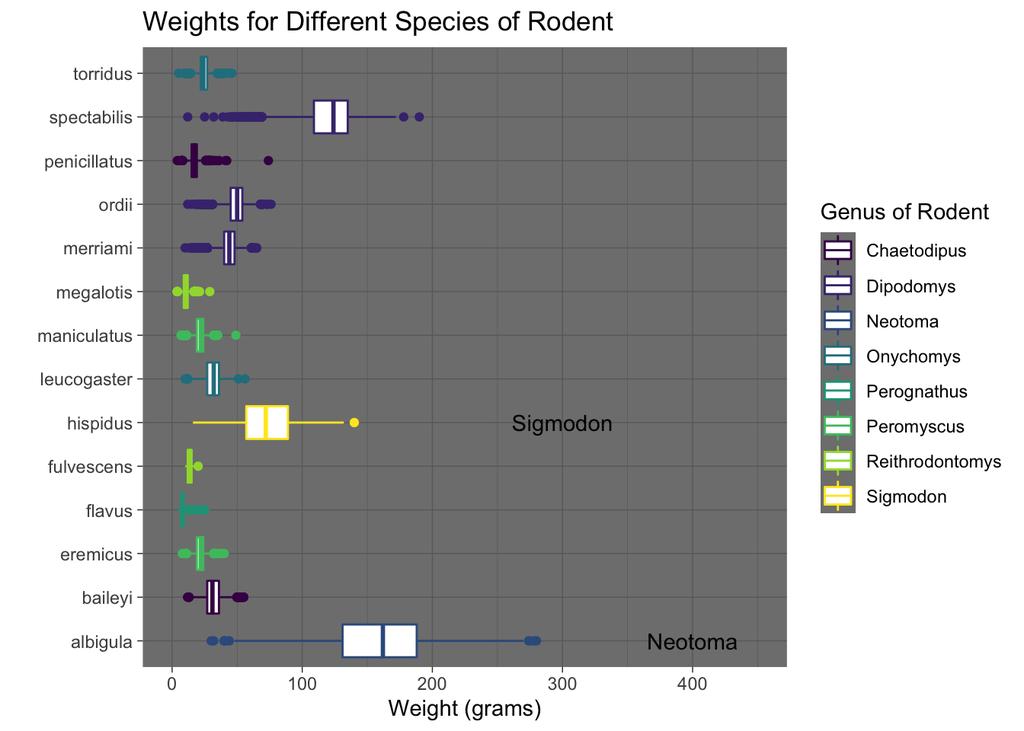

```r
ggplot(data = surveys, aes(x = weight, y = species, color = genus)) +
  geom_boxplot() +
  labs(title = "Weights for Different Species of Rodent",
       y = "",
       x = "Weight (grams)",
       color = "Genus of Rodent")+
  scale_color_viridis_d() +
  annotate("text", y = 1, x = 400, label = "Neotoma") +
  annotate("text", y = 6, x = 300, label = "Sigmodon") +
  xlim(0, 450) +
  theme_dark()
```

**Tip**

It is often easier to see colors with a darker background. Changing the theme of the background to `theme_dark()` does just that. There are lots of themes that change the background of a plot – check them out in the `?theme_dark()` help page.

> **For this challenge you are expected to use this information to modify the plot you created in question 13 or 14 (or the density ridges!). First, you are to color the boxplots based on `genus`. Next, you are to add annotations for each genus, next to the boxplot(s) associated with that genus. Finally, you are expected to use the `theme()` function to remove the color legend from the plot, since it is no longer needed!**

# 4 Challenge 2 Submission

Once you have completed your challenge(s) you should upload your rendered HTML file to Canvas.

**Separate from Lab 1**

Your Challenge 2 file **must** be separate from your Lab 2 file. Yes, some of the code for the Challenge is the same as Lab 1 – you can copy and paste this code into a **new** Quarto file. Your Challenge 2 submission should only included code necessary for completing the Challenge, nothing else.

**Only the HTML**

You will submit **only** your rendered HTML file. Your HTML file is required to have the following specifications in the YAML options (at the top of your document):

- be self-contained (`self-contained: true`)
- include your source code (`code-tools: true`)
- include all your code and output (`echo: true`)

**If any of the options are not included, your Lab 2 or Challenge 2 assignment will receive an “Incomplete” and you will be required to submit a revision.**